# MCBD: Synthesis of Metacoupled Effects on Biodiversity

Veronica F. Frans, CSIS Lab, Michigan State University

May 30, 2020 (Updated: September 4, 2020)

# 1. Methods summary

Synthesis of survey 2 and 3 results for metacoupling/biodiversity systematic review. It consists of response summaries and visualizations of the accepted papers.

# 2. R Setup

The script presented here was done using R (version 4.0.2; R Core Team 2020) and its packages.

Load libraries, directories, and custom functions from source file.

```r
# Source file
  source('Reference.R')
```

Data is stored here:

```
## [1] "C:/Users/niqui/OneDrive - Michigan State University/My Projects/Biodiv_Metacoupling/MCBD_Root/MCBD/data/"
```

Final tables are stored here:

```
## [1] "C:/Users/niqui/OneDrive - Michigan State University/My Projects/Biodiv_Metacoupling/MCBD_Root/MCBD/results/"
```

Final figures are stored here:

```
## [1] "C:/Users/niqui/OneDrive - Michigan State University/My Projects/Biodiv_Metacoupling/MCBD_Root/MCBD/images/"
```

For **this run** of the script, tables for manual checks will be stored in the following folder:

```
## [1] "C:/Users/niqui/OneDrive - Michigan State University/My Projects/Biodiv_Metacoupling/MCBD_Root/MCBD/issues/2020-09-04/"
```

# 3. Load data

```r
# surveys
  s23 <- read.csv(paste0(dat.dir,'s23.csv'))
```

Show column names

```r
# get col names
  colnames(s23)
```

```
##  [1] "paper_id"            "entry_id"            "taxon_or_func"
##  [4] "biodiv_cat_1sp"      "biodiv_cat_multsp"   "biodiv_cat_habitat"
##  [7] "scale"               "biodiv_temp_res"     "effect"
## [10] "significant"         "p_value"             "biodiv_countries"
## [13] "list_countries"      "data_source_meta"    "data_source_biodiv"
## [16] "tele_cat"            "data_type_meta"      "data_type_biodiv"
## [19] "habitat"             "list_continents"     "scale_entire"
## [22] "meta_var_type"       "peri_tele_flows"     "peri_tele_sep"
## [25] "peri_tele_sep_unk"   "scale_biodiv"        "num_biodiv_metrics"
## [28] "list_biodiv_metrics" "taxa"                "sig_effect"
```

# 4. First synthesis: Effects of coupling categories across taxa

## 4.1 Summary regardless of significance

Make a new table.

```r
# get summary
  taxa_flow <- ddply(s23, .(taxa, tele_cat, effect), summarize,
                # total count of entries
                count=length(taxa)) %>%
                # percents of effects within totals per taxa
                group_by(taxa) %>%
                  nest() %>%
                   mutate(perc_per_taxa=map(data, function(x) x$count/sum(x$count))) %>%
                    unnest()

# save as csv
  write.csv(taxa_flow, paste0(tab.dir,'synthesis_effects_taxa_and_flow.csv'),
            row.names = TRUE)

# view
  taxa_flow
```

| taxa | tele_cat | effect | count | perc_per_taxa |
| --- | --- | --- | --- | --- |
| Amphibians | Trade | Changed (e.g. species composition) | 1 | 1.000000000 |
| Birds | Energy Transfer | Negative (detrimental) | 6 | 0.015503876 |
| Birds | Energy Transfer | Neutral (only when there is absolutely no difference in metrics) | 8 | 0.020671835 |
| Birds | Energy Transfer | Positive (beneficial) | 9 | 0.023255814 |
| Birds | Investment | Negative (detrimental) | 4 | 0.010335917 |
| Birds | Investment | Positive (beneficial) | 6 | 0.015503876 |
| Birds | Knowledge Transfer | Changed (e.g. species composition) | 42 | 0.108527132 |
| Birds | Knowledge Transfer | Negative (detrimental) | 2 | 0.005167959 |
| Birds | Knowledge Transfer | Neutral (only when there is absolutely no difference in metrics) | 14 | 0.036175711 |
| Birds | Knowledge Transfer | Positive (beneficial) | 12 | 0.031007752 |

[output cut: 115 more lines]

Check levels

```r
levels(as.factor(taxa_flow$taxa))
```

```
## [1] "Amphibians"          "Birds"               "Fish"
## [4] "Invertebrates"       "Mammals"             "Multiple"
## [7] "Plants/Trees/Shrubs" "Reptiles"
```

Check levels

```r
levels(as.factor(taxa_flow$effect))
```

```
## [1] "Changed (e.g. species composition)"
## [2] "Negative (detrimental)"
## [3] "Neutral (only when there is absolutely no difference in metrics)"
## [4] "Positive (beneficial)"
## [5] "Unclear"
```

```r
levels(as.factor(taxa_flow$tele_cat))
```

```
##  [1] "Energy Transfer"       "Investment"            "Knowledge Transfer"
##  [4] "Migration (human)"     "Migration (non-human)" "Other"
##  [7] "remove"                "Species Dispersal"     "Tourism"
## [10] "Trade"                 "Waste Transfer"        "Water Transfer"
```

Adjust levels

```r
# taxa level change
  taxa_flow$taxa <- factor(taxa_flow$taxa,
                           c('Birds','Mammals','Reptiles','Amphibians',
                             'Fish','Invertebrates','Plants/trees/shrubs',
                             'Multiple'))

# effects level change
  taxa_flow$effect <- gsub("\\s*\\([^\\)]+\\)", '',
                          as.character(taxa_flow$effect))
  taxa_flow$effect <- factor(taxa_flow$effect,
                             c('Positive','Neutral','Negative','Changed','Unclear'))

# telecoupling level change
  taxa_flow$tele_cat <- factor(taxa_flow$tele_cat,
                               c("Energy Transfer","Investment","Knowledge Transfer",
                                 "Migration (human)","Migration (non-human)",
                                 "Species Dispersal","Technology Transfer",
                                 "Tourism","Trade","Waste Transfer","Water Transfer",
                                 "Other","remove"))
```

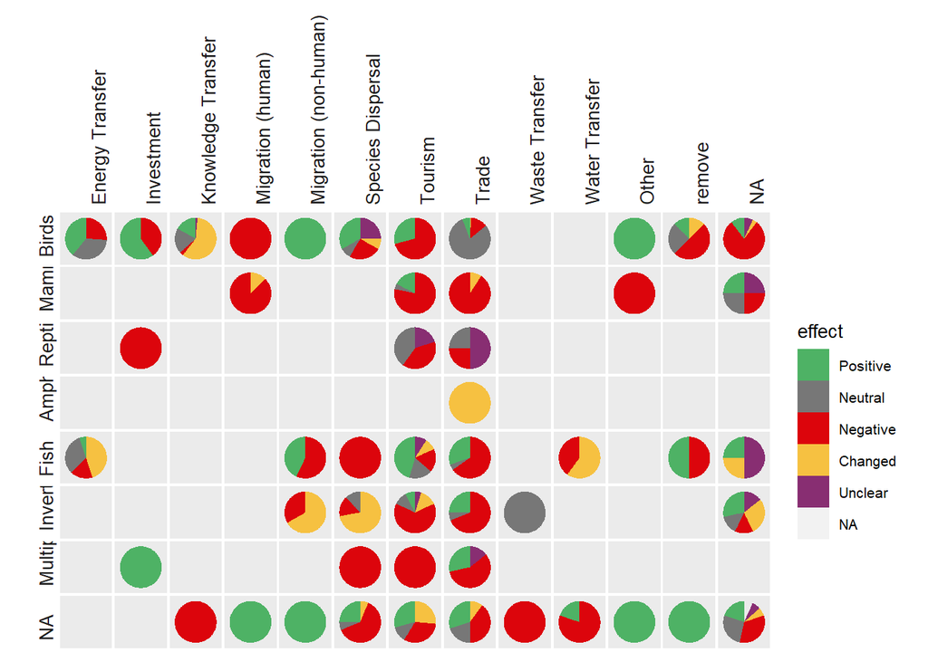

```r
# change colors
  #effect_cols <- c('#4EB265','#999999','#A50026','#FDB366','#9A709E')
  effect_cols <- c('#4EB265','#777777','#DC050C','#F6C141','#882E72')

# Matrix of pie charts
  taxa_flow_fig <- ggplot(taxa_flow) +
                    aes(x='', y = count, fill = effect) +
                    geom_bar(position='fill',
                             stat='identity', width = 1, size = 0.01) +
                    # activate for vertical or horizontal version
                      facet_grid(taxa ~ tele_cat, switch='y') + #horizontal
                      #facet_grid(tele_cat ~ taxa, switch='y') +  #vertical
                    # convert to pie chart
                      coord_polar(theta = 'y') +
                    # colors
                      scale_fill_manual(
                        values=effect_cols,
                        guide = guide_legend(reverse = FALSE))  +
                        scale_y_discrete(expand=c(0,0))+
                    # style
                      theme_gray(base_size=10)+
                      theme(
                        axis.title=element_blank(),
                        axis.line=element_blank(),
                        axis.ticks=element_blank(),
                        axis.text=element_blank(),
                        panel.border = element_blank(),
                        panel.grid=element_blank(),
                        panel.grid.major = element_blank(),
                        panel.grid.minor = element_blank(),
                        plot.background = element_rect(),
                        plot.title=element_blank(),
                        strip.text.x = element_text(size=10,
                                          angle=90, vjust=0, hjust = 0),
                        strip.text.y = element_text(size=10,
                                          angle=180, vjust=0, hjust = 0),
                        strip.background = element_rect(fill='white'),
                        panel.spacing = unit(0.1, 'lines')
                        ) +
                    # labels
                      ylab('') + xlab('')

# save image
  ggsave(taxa_flow_fig,
         filename=paste0(fig.dir,
                         #'synthesis_effects_taxa_and_flow_Vert.png'),
                         'synthesis_effects_taxa_and_flow_Horz.png'),
         #height=6.5,width=7,units='in',
         dpi=600)


# display image
  taxa_flow_fig
```

## 4.2 Summary emphasizing significance

Make a new column for significant effects; non-significant becomes a new level in this dataset.

```r
# new column of significant effects; non-significant effects renamed
  s23$sig_effect <- ''
  s23$sig_effect <- as.character(s23$significant)
  s23$effect <- as.character(s23$effect)
  s23$sig_effect[is.na(s23$sig_effect)] <- "Unknown Signif."
  s23$sig_effect[s23$sig_effect=='Not evaluated'] <- "Unknown Signif."
  s23$sig_effect[s23$sig_effect=='FALSE'] <- "Not Signif."
  s23$sig_effect[s23$sig_effect=='TRUE'] <- s23$effect[s23$sig_effect=='TRUE']
```

Summarize new column by taxa and telecoupling category.

```r
# get summary
  taxa_flow_sig <- ddply(s23, .(taxa, tele_cat, sig_effect), summarize,
                        # total count of entries
                        count=length(taxa))
# save as csv
  write.csv(taxa_flow_sig,
            paste0(tab.dir,'synthesis_effects_taxa_and_flow_significant.csv'),
            row.names = TRUE)

# view
  taxa_flow_sig
```

| taxa | tele_cat | sig_effect | count |
| --- | --- | --- | --- |
| Amphibians | Trade | Changed (e.g. species composition) | 1 |
| Birds | Energy Transfer | Negative (detrimental) | 6 |
| Birds | Energy Transfer | Not Signif. | 8 |
| Birds | Energy Transfer | Positive (beneficial) | 9 |
| Birds | Investment | Negative (detrimental) | 4 |
| Birds | Investment | Not Signif. | 4 |
| Birds | Investment | Positive (beneficial) | 2 |
| Birds | Knowledge Transfer | Changed (e.g. species composition) | 42 |
| Birds | Knowledge Transfer | Negative (detrimental) | 2 |
| Birds | Knowledge Transfer | Neutral (only when there is absolutely no difference in metrics) | 1 |

[output cut: 121 more lines]

Change levels

```r
# taxa level change
  taxa_flow_sig$taxa <- factor(taxa_flow_sig$taxa,
                           c('Birds','Mammals','Reptiles','Amphibians',
                             'Fish','Invertebrates','Plants/trees/shrubs',
                             'Multiple','Undefined'))

# effects level change
  taxa_flow_sig$sig_effect <- gsub("\\s*\\([^\\)]+\\)", '',
                          as.character(taxa_flow_sig$sig_effect))
  taxa_flow_sig$sig_effect <- factor(taxa_flow_sig$sig_effect,
                             c('Positive','Neutral','Negative','Changed',
                               'Not Signif.',
                               'Unknown Signif.',
                               'Unclear'))

# telecoupling level change
  taxa_flow_sig$tele_cat <- factor(taxa_flow_sig$tele_cat,
                               c("Energy Transfer","Investment","Knowledge Transfer",
                                 "Migration (human)","Migration (non-human)",
                                 "Species Dispersal","Technology Transfer",
                                 "Tourism","Trade","Waste Transfer","Water Transfer",
                                 "Other","remove"))
```

Visualize as a matrix of pie charts

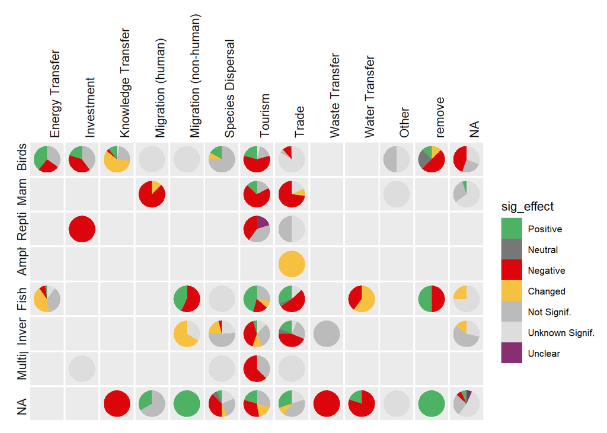

```r
# change colors
  #effect_cols <- c('#4EB265','#999999','#A50026','#FDB366','#9A709E')
  #effect_cols <- c('#4EB265','#777777','#DC050C','#F6C141','#882E72')
  sig_effect_cols <- c('#4EB265','#777777','#DC050C','#F6C141',
                       # include 'Not Signif.' and 'Unknown Signif.'
                       '#BBBBBB','#DDDDDD',
                       # 'unclear' keeps same color as before
                       '#882E72')

# Matrix of pie charts
  taxa_flow_fig <- ggplot(taxa_flow_sig) +
                    aes(x='', y = count, fill = sig_effect) +
                    geom_bar(position='fill',
                             stat='identity', width = 1, size = 0.01) +
                    # activate for vertical or horizontal version
                      facet_grid(taxa ~ tele_cat, switch='y') + #horizontal
                      #facet_grid(tele_cat ~ taxa, switch='y') +  #vertical
                    # convert to pie chart
                      coord_polar(theta = 'y') +
                    # colors
                      scale_fill_manual(
                        values=sig_effect_cols,
                        guide = guide_legend(reverse = FALSE))  +
                        scale_y_discrete(expand=c(0,0))+
                    # style
                      theme_gray(base_size=10)+
                      theme(
                        axis.title=element_blank(),
                        axis.line=element_blank(),
                        axis.ticks=element_blank(),
                        axis.text=element_blank(),
                        panel.border = element_blank(),
                        panel.grid=element_blank(),
                        panel.grid.major = element_blank(),
                        panel.grid.minor = element_blank(),
                        plot.background = element_rect(),
                        plot.title=element_blank(),
                        strip.text.x = element_text(size=10,
                                          angle=90, vjust=0, hjust = 0),
                        strip.text.y = element_text(size=10,
                                          angle=0, vjust=0, hjust = 0),
                        strip.background = element_rect(fill='white'),
                        panel.spacing = unit(0.1, 'lines')
                        ) +
                    # labels
                      ylab('') + xlab('')

# save image
  ggsave(taxa_flow_fig,
         filename=paste0(fig.dir,
                         # activate for vertical or horizontal version
                           #'synthesis_effects_taxa_and_flow_significant_Vert.png'),
                           'synthesis_effects_taxa_and_flow_significant_Horz.png'),
         #height=6.5,width=7,units='in',
         dpi=600)


# display image
  taxa_flow_fig
```

# 5. Second synthesis: Effects by coupling and metric categories

## 5.1 New dataset (long format)

Convert to long format, where metric is indicated.

```r
# subset
  metrics <- subset(s23,
                    select=c('paper_id','entry_id',
                            'taxa','tele_cat','effect',
                            'biodiv_cat_1sp',
                            'biodiv_cat_multsp',
                            'biodiv_cat_habitat'))
# melt
  metrics_long <- melt(metrics, id.vars=c('paper_id','entry_id',
                            'taxa','tele_cat','effect'))

# remove NA fields
  metrics_long <- metrics_long[!is.na(metrics_long$value),]
```

Rename last columns

```r
# change colnames
  colnames(metrics_long)[6] <- 'metric_type'
  colnames(metrics_long)[7] <- 'metric'
```

Rename metric types

```r
# check levels
  levels(metrics_long$metric_type)
```

```
## [1] "biodiv_cat_1sp"     "biodiv_cat_multsp"  "biodiv_cat_habitat"
```

```r
# change levels
  levels(metrics_long$metric_type) <- c('single species',
                                        'multiple species',
                                        'habitat')
```

Rename metrics

```r
# check levels
  levels(as.factor(metrics_long$metric))
```

```
##  [1] "Abundance/Density (biomass, mass, number of individuals, individuals/unit area)"
##  [2] "Abundance/Density (number of individuals, individuals/unit area, biomass)"
##  [3] "Amount (e.g. land use change from non-habitat to habitat)"
##  [4] "Composition (what species?)"
##  [5] "Diversity index (Shannon-Weiner, Simpson's, Inverse Simpson's, etc.)"
##  [6] "Evenness"
##  [7] "Movement"
##  [8] "Occurrence"
##  [9] "Occurrence (presence, range, persistence, etc., NOT detection)"
## [10] "Population dynamics (survival, fitness, reproduction, mortality, etc.)"
## [11] "Quality (pollution, connectence, disturbance, etc.)"
## [12] "Richness (number of species)"
## [13] "With-in species diversity (genetic diversity, age structure, etc.)"
```

```r
# remove parentheses
  metrics_long$metric <- gsub("\\s*\\([^\\)]+\\)", '',
                          as.character(metrics_long$metric))

# capitalize each word
  metrics_long$metric <- tools::toTitleCase(metrics_long$metric)

# adjust name
  metrics_long$metric <- gsub("With-in", 'Within',
                        as.character(metrics_long$metric))

# change levels, moving other to the end
  metrics_long$metric <- factor(metrics_long$metric,
                                c("Abundance/Density",
                                   "Amount",
                                   "Composition",
                                   "Detection",
                                   "Diversity Index",
                                   "Evenness",
                                   "Movement",
                                   "Occurrence",
                                   "Population Dynamics",
                                   "Quality",
                                   "Richness",
                                   "Within Species Diversity",
                                   "Other"))

# check levels
  levels(as.factor(metrics_long$metric))
```

```
##  [1] "Abundance/Density"        "Amount"
##  [3] "Composition"              "Detection"
##  [5] "Diversity Index"          "Evenness"
##  [7] "Movement"                 "Occurrence"
##  [9] "Population Dynamics"      "Quality"
## [11] "Richness"                 "Within Species Diversity"
## [13] "Other"
```

## 5.2 Summary regardless of significance

### 5.2.1 Summary table

Make a new table summarizing dataset by metric, coupling category and effect

```r
# get summary
  metric_flow <- ddply(metrics_long,
                       .(metric_type, metric, tele_cat, effect),
                       summarize,
                      # total count of entries
                        count=length(metric))

# save as csv
  write.csv(metric_flow, paste0(tab.dir,'synthesis_effects_metric_and_flow.csv'),
            row.names = TRUE)

# view
  metric_flow
```

| metric_type | metric | tele_cat | effect | count |
| --- | --- | --- | --- | --- |
| single species | Abundance/Density | Energy Transfer | Negative (detrimental) | 10 |
| single species | Abundance/Density | Energy Transfer | Neutral (only when there is absolutely no difference in metrics) | 8 |
| single species | Abundance/Density | Energy Transfer | Positive (beneficial) | 6 |
| single species | Abundance/Density | Investment | Negative (detrimental) | 2 |
| single species | Abundance/Density | Knowledge Transfer | Changed (e.g. species composition) | 41 |
| single species | Abundance/Density | Knowledge Transfer | Neutral (only when there is absolutely no difference in metrics) | 11 |
| single species | Abundance/Density | Knowledge Transfer | Positive (beneficial) | 1 |
| single species | Abundance/Density | Knowledge Transfer | Unclear | 1 |
| single species | Abundance/Density | Migration (human) | Negative (detrimental) | 5 |
| single species | Abundance/Density | Migration (human) | Positive (beneficial) | 3 |

[output cut: 179 more lines]

Change levels

```r
# effects level change
  metric_flow$effect <- gsub("\\s*\\([^\\)]+\\)", '',
                          as.character(metric_flow$effect))
  metric_flow$effect <- factor(metric_flow$effect,
                             c('Positive','Neutral','Negative','Changed','Unclear'))

# telecoupling level change
  metric_flow$tele_cat <- factor(metric_flow$tele_cat,
                               c("Energy Transfer","Investment","Knowledge Transfer",
                                 "Migration (human)","Migration (non-human)",
                                 "Species Dispersal","Technology Transfer",
                                 "Tourism","Trade","Waste Transfer","Water Transfer",
                                 "Other","remove"))
```

### 5.2.2 Pie chart with all metrics combined

Visualize as a matrix of pie charts. First, **ALL** metrics together.

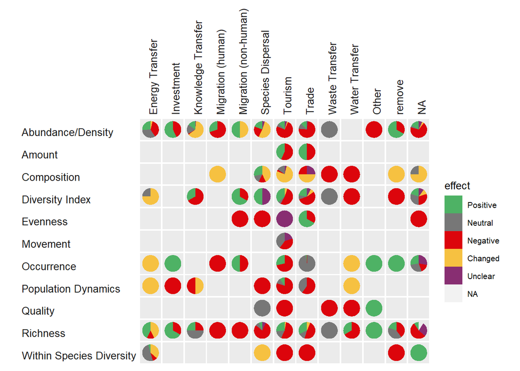

```r
# change colors
  effect_cols <- c('#4EB265','#777777','#DC050C','#F6C141','#882E72')

# Matrix of pie charts
  metric_flow_fig <- ggplot(metric_flow) +
                    aes(x='', y = count, fill = effect) +
                    geom_bar(position='fill',
                             stat='identity', width = 1, size = 0.01) +
                    # activate for vertical or horizontal version
                      facet_grid(metric ~ tele_cat, switch='y') + #horizontal
                      #facet_grid(tele_cat ~ metric, switch='y') +  #vertical
                    # convert to pie chart
                      coord_polar(theta = 'y') +
                    # colors
                      scale_fill_manual(
                        values=effect_cols,
                        guide = guide_legend(reverse = FALSE))  +
                        scale_y_discrete(position='right',expand=c(0,0))+
                    # style
                      theme_gray(base_size=10)+
                      theme(
                        axis.title=element_blank(),
                        axis.line=element_blank(),
                        axis.ticks=element_blank(),
                        axis.text=element_blank(),
                        panel.border = element_blank(),
                        panel.grid=element_blank(),
                        panel.grid.major = element_blank(),
                        panel.grid.minor = element_blank(),
                        plot.background = element_rect(),
                        plot.title=element_blank(),
                        strip.text.x = element_text(size=10,
                                          angle=90, vjust=0, hjust = 0),
                        strip.text.y.left = element_text(size=10,
                                          angle=0, vjust=0, hjust = 0),
                        strip.background = element_rect(fill='white'),
                        panel.spacing = unit(0.1, 'lines')
                        ) +
                    # labels
                      ylab('') + xlab('')

# save image
  ggsave(metric_flow_fig,
         filename=paste0(fig.dir,
                         #'synthesis_effects_metric_and_flow_Vert.png'),
                         'synthesis_effects_metric_and_flow_Horz.png'),
         #height=6.5,width=7,units='in',
         dpi=600)


# display image
  metric_flow_fig
```

## 5.2.3 Pie chart separating metric categories

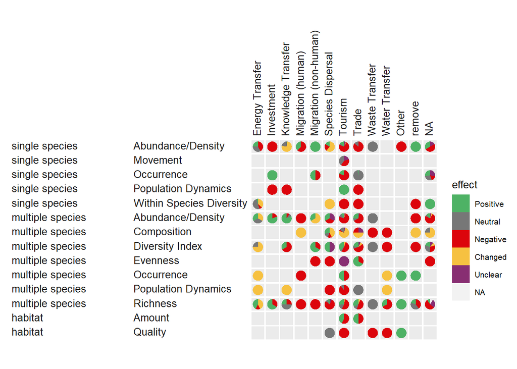

```r
# change colors
  effect_cols <- c('#4EB265','#777777','#DC050C','#F6C141','#882E72')

# Matrix of pie charts
  metric_flow_fig <- ggplot(metric_flow) +
                    aes(x='', y = count, fill = effect) +
                    geom_bar(position='fill',
                             stat='identity', width = 1, size = 0.01) +
                    # activate for vertical or horizontal version
                      facet_grid(metric_type ~ metric ~ tele_cat, switch='y') + #horizontal
                      #facet_grid(tele_cat ~ metric, switch='y') +  #vertical
                    # convert to pie chart
                      coord_polar(theta = 'y') +
                    # colors
                      scale_fill_manual(
                        values=effect_cols,
                        guide = guide_legend(reverse = FALSE))  +
                        scale_y_discrete(position='right',expand=c(0,0))+
                    # style
                      theme_gray(base_size=10)+
                      theme(
                        axis.title=element_blank(),
                        axis.line=element_blank(),
                        axis.ticks=element_blank(),
                        axis.text=element_blank(),
                        panel.border = element_blank(),
                        panel.grid=element_blank(),
                        panel.grid.major = element_blank(),
                        panel.grid.minor = element_blank(),
                        plot.background = element_rect(),
                        plot.title=element_blank(),
                        strip.text.x = element_text(size=10,
                                          angle=90, vjust=0, hjust = 0),
                        strip.text.y.left = element_text(size=10,
                                          angle=0, vjust=0, hjust = 0),
                        strip.background = element_rect(fill='white'),
                        panel.spacing = unit(0.1, 'lines')
                        ) +
                    # labels
                      ylab('') + xlab('')

# save image
  ggsave(metric_flow_fig,
         filename=paste0(fig.dir,
                         #'synthesis_effects_metric_type_and_flow_Vert.png'),
                         'synthesis_effects_metric_type_and_flow_Horz.png'),
         #height=6.5,width=7,units='in',
         dpi=600)


# display image
  metric_flow_fig
```

## 5.3 Summary emphasizing significance

### 5.3.1 New dataset (long format)

Convert to long format, where metric is indicated and the significant effect category is used instead.

```r
# subset
  sig_metrics <- subset(s23,
                    select=c('paper_id','entry_id',
                            'taxa','tele_cat',
                            'sig_effect', ##<--- THIS IS THE CHANGE HERE
                            'biodiv_cat_1sp',
                            'biodiv_cat_multsp',
                            'biodiv_cat_habitat'))
# melt
  sig_met_long <- melt(sig_metrics, id.vars=c('paper_id','entry_id',
                            'taxa','tele_cat','sig_effect'))

# remove NA fields
  sig_met_long <- sig_met_long[!is.na(sig_met_long$value),]
```

Rename last columns

```r
# change colnames
  colnames(sig_met_long)[6] <- 'metric_type'
  colnames(sig_met_long)[7] <- 'metric'
```

Rename metric types

```r
# check levels
  levels(sig_met_long$metric_type)
```

```
## [1] "biodiv_cat_1sp"     "biodiv_cat_multsp"  "biodiv_cat_habitat"
```

```r
# change levels
  levels(sig_met_long$metric_type) <- c('single species',
                                        'multiple species',
                                        'habitat')
```

Rename metrics

```r
# check levels
  levels(as.factor(sig_met_long$metric))
```

```
##  [1] "Abundance/Density (biomass, mass, number of individuals, individuals/unit area)"
##  [2] "Abundance/Density (number of individuals, individuals/unit area, biomass)"
##  [3] "Amount (e.g. land use change from non-habitat to habitat)"
##  [4] "Composition (what species?)"
##  [5] "Diversity index (Shannon-Weiner, Simpson's, Inverse Simpson's, etc.)"
##  [6] "Evenness"
##  [7] "Movement"
##  [8] "Occurrence"
##  [9] "Occurrence (presence, range, persistence, etc., NOT detection)"
## [10] "Population dynamics (survival, fitness, reproduction, mortality, etc.)"
## [11] "Quality (pollution, connectence, disturbance, etc.)"
## [12] "Richness (number of species)"
## [13] "With-in species diversity (genetic diversity, age structure, etc.)"
```

```r
# remove parentheses
  sig_met_long$metric <- gsub("\\s*\\([^\\)]+\\)", '',
                          as.character(sig_met_long$metric))

# capitalize each word
  sig_met_long$metric <- tools::toTitleCase(sig_met_long$metric)

# adjust name
  sig_met_long$metric <- gsub("With-in", 'Within',
                        as.character(sig_met_long$metric))

# change levels, moving other to the end
  sig_met_long$metric <- factor(sig_met_long$metric,
                                c("Abundance/Density",
                                   "Amount",
                                   "Composition",
                                   "Detection",
                                   "Diversity Index",
                                   "Evenness",
                                   "Movement",
                                   "Occurrence",
                                   "Population Dynamics",
                                   "Quality",
                                   "Richness",
                                   "Within Species Diversity",
                                   "Other"))

# check levels
  levels(as.factor(sig_met_long$metric))
```

```
##  [1] "Abundance/Density"        "Amount"
##  [3] "Composition"              "Detection"
##  [5] "Diversity Index"          "Evenness"
##  [7] "Movement"                 "Occurrence"
##  [9] "Population Dynamics"      "Quality"
## [11] "Richness"                 "Within Species Diversity"
## [13] "Other"
```

Make a new table summarizing dataset by metric, coupling category and significant effect

```r
# get summary
  met_flow_sig <- ddply(sig_met_long,
                       .(metric_type, metric, tele_cat, sig_effect),
                       summarize,
                      # total count of entries
                        count=length(metric))

# save as csv
  write.csv(met_flow_sig,
            paste0(tab.dir,
                   'synthesis_effects_metric_and_flow_significant.csv'),
            row.names = FALSE)

# view
  met_flow_sig
```

| metric_type | metric | tele_cat | sig_effect | count |
| --- | --- | --- | --- | --- |
| single species | Abundance/Density | Energy Transfer | Negative (detrimental) | 8 |
| single species | Abundance/Density | Energy Transfer | Not Signif. | 10 |
| single species | Abundance/Density | Energy Transfer | Positive (beneficial) | 6 |
| single species | Abundance/Density | Investment | Negative (detrimental) | 2 |
| single species | Abundance/Density | Knowledge Transfer | Changed (e.g. species composition) | 41 |
| single species | Abundance/Density | Knowledge Transfer | Not Signif. | 11 |
| single species | Abundance/Density | Knowledge Transfer | Positive (beneficial) | 1 |
| single species | Abundance/Density | Knowledge Transfer | Unknown Signif. | 1 |
| single species | Abundance/Density | Migration (human) | Negative (detrimental) | 5 |
| single species | Abundance/Density | Migration (human) | Not Signif. | 2 |

[output cut: 189 more lines]

Change levels

```r
# effects level change
  met_flow_sig$sig_effect <- gsub("\\s*\\([^\\)]+\\)", '',
                          as.character(met_flow_sig$sig_effect))
  met_flow_sig$sig_effect <- factor(met_flow_sig$sig_effect,
                              c('Positive','Neutral','Negative','Changed',
                               'Not Signif.',
                               'Unknown Signif.',
                               'Unclear'))

# telecoupling level change
  met_flow_sig$tele_cat <- factor(met_flow_sig$tele_cat,
                               c("Energy Transfer","Investment","Knowledge Transfer",
                                 "Migration (human)","Migration (non-human)",
                                 "Species Dispersal","Technology Transfer",
                                 "Tourism","Trade","Waste Transfer","Water Transfer",
                                 "Other","remove"))
```

### 5.3.2 Pie chart with all metrics combined

Visualize as a matrix of pie charts. First, **ALL** metrics together.

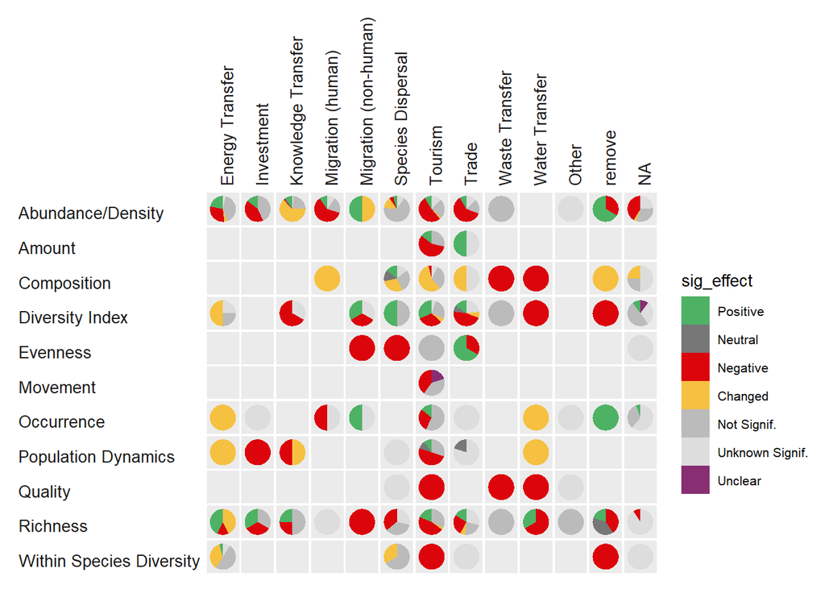

```r
# Matrix of pie charts
  met_flow_sig_fig <- ggplot(met_flow_sig) +
                    aes(x='', y = count, fill = sig_effect) +
                    geom_bar(position='fill',
                             stat='identity', width = 1, size = 0.01) +
                    # activate for vertical or horizontal version
                      facet_grid(metric ~ tele_cat, switch='y') + #horizontal
                      #facet_grid(tele_cat ~ metric, switch='y') +  #vertical
                    # convert to pie chart
                      coord_polar(theta = 'y') +
                    # colors
                      scale_fill_manual(
                        values=sig_effect_cols,
                        guide = guide_legend(reverse = FALSE))  +
                        scale_y_discrete(position='right',expand=c(0,0))+
                    # style
                      theme_gray(base_size=10)+
                      theme(
                        axis.title=element_blank(),
                        axis.line=element_blank(),
                        axis.ticks=element_blank(),
                        axis.text=element_blank(),
                        panel.border = element_blank(),
                        panel.grid=element_blank(),
                        panel.grid.major = element_blank(),
                        panel.grid.minor = element_blank(),
                        plot.background = element_rect(),
                        plot.title=element_blank(),
                        strip.text.x = element_text(size=10,
                                          angle=90, vjust=0, hjust = 0),
                        strip.text.y.left = element_text(size=10,
                                          angle=0, vjust=0, hjust = 0),
                        strip.background = element_rect(fill='white'),
                        panel.spacing = unit(0.1, 'lines')
                        ) +
                    # labels
                      ylab('') + xlab('')

# save image
  ggsave(met_flow_sig_fig,
         filename=paste0(fig.dir,
         # activate for vertical or horizontal version
           #'synthesis_effects_metric_and_flow_significant_Vert.png'),
           'synthesis_effects_metric_and_flow_significant_Horz.png'),
         #height=6.5,width=7,units='in',
         dpi=600)


# display image
  met_flow_sig_fig
```

## 5.3.3 Pie chart separating metric categories

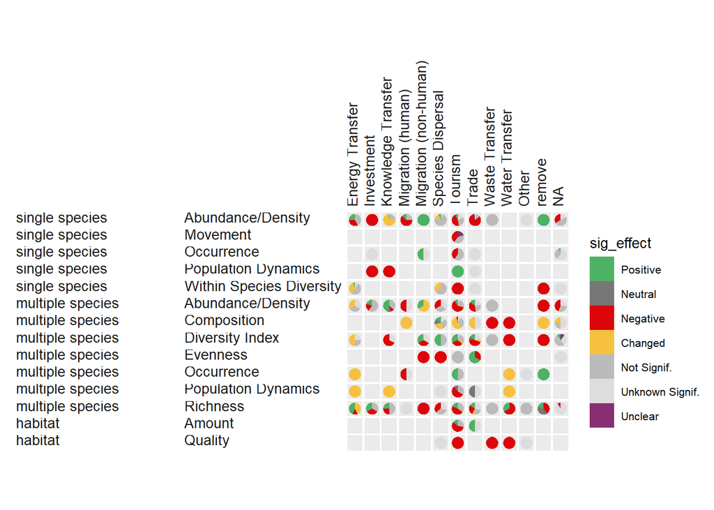

```r
# Matrix of pie charts
  met_flow_sig_fig <- ggplot(met_flow_sig) +
                    aes(x='', y = count, fill = sig_effect) +
                    geom_bar(position='fill',
                             stat='identity', width = 1, size = 0.01) +
                    # activate for vertical or horizontal version
                      facet_grid(metric_type ~ metric ~ tele_cat, switch='y') + #horizontal
                      #facet_grid(tele_cat ~ metric, switch='y') +  #vertical
                    # convert to pie chart
                      coord_polar(theta = 'y') +
                    # colors
                      scale_fill_manual(
                        values=sig_effect_cols,
                        guide = guide_legend(reverse = FALSE))  +
                        scale_y_discrete(position='right',expand=c(0,0))+
                    # style
                      theme_gray(base_size=10)+
                      theme(
                        axis.title=element_blank(),
                        axis.line=element_blank(),
                        axis.ticks=element_blank(),
                        axis.text=element_blank(),
                        panel.border = element_blank(),
                        panel.grid=element_blank(),
                        panel.grid.major = element_blank(),
                        panel.grid.minor = element_blank(),
                        plot.background = element_rect(),
                        plot.title=element_blank(),
                        strip.text.x = element_text(size=10,
                                          angle=90, vjust=0, hjust = 0),
                        strip.text.y.left = element_text(size=10,
                                          angle=0, vjust=0, hjust = 0),
                        strip.background = element_rect(fill='white'),
                        panel.spacing = unit(0.1, 'lines')
                        ) +
                    # labels
                      ylab('') + xlab('')

# save image
  ggsave(met_flow_sig_fig,
         filename=paste0(fig.dir,
         # activate for vertical or horizontal version
           #'synthesis_effects_metric_type_and_flow_significant_Vert.png'),
           'synthesis_effects_metric_type_and_flow_significant_Horz.png'),
         height=6,width=14,units='in',
         dpi=600)


# display image
  met_flow_sig_fig
```